# **Advanced lecture: Gaussian process 기반 multi-fidelity 모델 (Co-Kriging) 실습**

By Mingyu Lee, Hwisang Jo, and Ikjin Lee

http://idol.kaist.ac.kr/

mglee91@kaist.ac.kr

IDOL Lab at KAIST

### **< Source papers >**

- Le Gratiet, L. (2013). Multi-fidelity Gaussian process regression for computer experiments (Doctoral dissertation, Université Paris-Diderot-Paris VII).
- **Lee, M.**, Jung, Y., Choi, J., & Lee, I. (2022). A reanalysis-based multi-fidelity (RBMF) surrogate framework for efficient structural optimization. Computers & Structures, 273, 106895.

Original source codes from https://github.com/SMTorg/SMT

Modified version by Mingyu Lee

### **< Contents >**

1) One-dimensional Kriging example

2) Two-dimensional Kriging example

**3) One-dimensional Co-Kriging example**

4) Bayesian optimization

# **3) One-dimensional Co-Kriging example**

## **▣ Multi-fidelity (MF) 이론 설명**

- **Surrogate model:** 입력과 출력 관계를 수학적으로 모델링하는 과정
- **Single-fidelity surrogate model:** 한가지의 충실도 데이터를 사용하여 대리모델 구성
- **Multi-fidelity surrogate model:** 다수의 충실도 데이터를 결합하여 효율적으로 대리모델 구성  
  **▷ High-fidelity (HF) data:** 정확하고 비싼 데이터 (Correction term)  
  **▷ Low-fidelity (LF) data:** 비교적 덜 정확하지만 값싼 데이터 (Ttrend term)  
  **▷ Types:** Co-Kriging, Hierarchical Kriging, etc

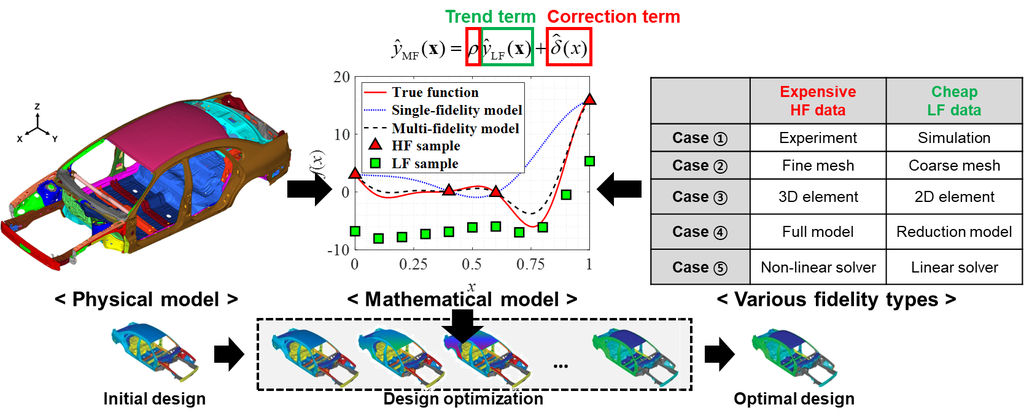

### ※ **예제 문제**

```python
from __future__ import print_function, division
import numpy as np
from matplotlib import pyplot as plt
from smt.applications import MFK
%matplotlib inline

from scipy import linalg
from smt.utils import compute_rms_error

from smt.problems import Sphere, NdimRobotArm, Rosenbrock
from smt.sampling_methods import LHS
from smt.surrogate_models import LS, QP, KPLS, KRG, KPLSK, GEKPLS, MGP
try:
    from smt.surrogate_models import IDW, RBF, RMTC, RMTB
    compiled_available = True
except:
    compiled_available = False

try:
    import matplotlib.pyplot as plt
    plot_status = True
except:
    plot_status = False

import scipy.interpolate

from mpl_toolkits.mplot3d import Axes3D
import matplotlib.pyplot as plt
from matplotlib import cm
```

## **Step 1: 인풋 정보 (or 전처리 과정)**

```python
ndim = 1
def HF_function(x): # HF 함수
    return ((x*6-2)**2)*np.sin((x*6-2)*2)

def LF_function(x): # LF 함수
    return 0.5*((x*6-2)**2)*np.sin((x*6-2)*2)+10*(x-0.5) - 5
```

## **Step2: 실험계획법 (DOE)**

```python
# HF 인풋 데이터
xt_HF = np.array([0.0, 0.4, 0.6, 1.])

# LF 인풋 데이터
xt_LF = np.array([0.0, 0.2, 0.4, 0.6, 0.8, 1.])
```

```python
print("HF input data",xt_HF)
print("LF input data",xt_LF)
```

```
HF input data [0.  0.4 0.6 1. ]
LF input data [0.  0.2 0.4 0.6 0.8 1. ]
```

## **Step 3: 데이터 생성 (시뮬레이션 or 실험)**

```python
# 아웃풋 데이터 생성 (실제 시뮬레이션 혹은 실험 수행)
yt_HF = HF_function(xt_HF) # 실제 HF 아웃풋 데이터 생성
yt_LF = LF_function(xt_LF) # 실제 LF 아웃풋 데이터 생성
```

```python
print("HF output data",yt_HF)
print("LF output data",yt_LF)
```

```
HF output data [ 3.02720998  0.11477697 -0.14943781 15.82973195]
LF output data [-8.48639501 -8.31986355 -5.94261151 -4.0747189  -4.47456522  7.91486597]
```

## **Step 4: 대리 모델 구성 (Co-Kriging)**

```python
# 대리모델링 (Main process, Co Kriging)
initial_theta = [0.1]*ndim # 초기 하이퍼파라미터 설정
sm_MF = MFK(theta0 = initial_theta, theta_bounds = [1e-6, 20], use_het_noise = False,
         propagate_uncertainty = False, n_start = 1)
sm_MF.set_training_values(xt_LF, yt_LF, name = 0) # LF 데이터 입력
sm_MF.set_training_values(xt_HF, yt_HF) # HF 데이터 입력
sm_MF.train() # 하이퍼파라미터 최적화
```

```
___________________________________________________________________________

                                    MFK
___________________________________________________________________________

 Problem size

      # training points.        : 4

___________________________________________________________________________

 Training

   Training ...
   Training - done. Time (sec):  0.0289524
```

```python
# 대리모델링 (Main process, Kriging)
sm_HF_only = KRG(theta0 = initial_theta)
sm_HF_only.set_training_values(xt_HF, yt_HF)
sm_HF_only.train() # 하이퍼파라미터 최적화
```

```
___________________________________________________________________________

                                  Kriging
___________________________________________________________________________

 Problem size

      # training points.        : 4

___________________________________________________________________________

 Training

   Training ...
   Training - done. Time (sec):  0.0918093
```

```python
# 예측값 및 불확실 정보 (테스트)
x_want = np.array([0.2]) # 예측 포인트
y_want_MF = sm_MF.predict_values(x_want) # MF 예측값
s2_want_MF = np.sqrt(sm_MF.predict_variances(x_want)) # MF 불확실 정보

y_want_HF_only = sm_HF_only.predict_values(x_want) # HF 예측값
s2_want_HF_only = np.sqrt(sm_HF_only.predict_variances(x_want)) # HF 불확실 정보

y_real = HF_function(x_want) # 실제값
```

```
___________________________________________________________________________

 Evaluation

      # eval points. : 1

   Predicting ...
   Predicting - done. Time (sec):  0.0000000

   Prediction time/pt. (sec) :  0.0000000

___________________________________________________________________________

 Evaluation

      # eval points. : 1

   Predicting ...
   Predicting - done. Time (sec):  0.0009973

   Prediction time/pt. (sec) :  0.0009973
```

```python
print("실제값",y_real)
print("예측값 (MF)","불확실 정보 (MF)",y_want_MF,s2_want_MF)
print("예측값 (HF)","불확실 정보 (HF)",y_want_HF_only,s2_want_HF_only)
```

```
실제값 [-0.63972711]
예측값 (MF) 불확실 정보 (MF) [[-0.6397202]] [[0.00037096]]
예측값 (HF) 불확실 정보 (HF) [[2.4701163]] [[3.22501345]]
```

## **후처리 과정 (Multi-fidelity surrogate model vs Single-fidelity surrogate model)**

```python
# 시각화 (Post-processing)
num = 100
x = np.linspace(0.0, 1.0, num).reshape(-1, 1) # 0에서 1까지 등간격으로 num개의 x값을 생성

y_true_HF = HF_function(x) # 실제 HF 값
y_true_LF = LF_function(x) # 실제 LF 값

# MF (Co Kriging)
y_MF = sm_MF.predict_values(x) # MF의 예측값
var_MF = sm_MF.predict_variances(x) # MF의 불확실 정보

# LF (Kriging) --> Co Kriging이 만들어지면서 자연스럽게 생성됨
y_LF = sm_MF._predict_intermediate_values(x, 1) # LF의 예측값
var_LF, _ =  sm_MF.predict_variances_all_levels(x) # LF의 불확실 정보

# HF (Kriging)
y_HF_only = sm_HF_only.predict_values(x) # HF의 예측값
var_HF_only = sm_HF_only.predict_variances(x) # HF의 불확실 정보
```

```
___________________________________________________________________________

 Evaluation

      # eval points. : 100

   Predicting ...
   Predicting - done. Time (sec):  0.0010147

   Prediction time/pt. (sec) :  0.0000101

___________________________________________________________________________

 Evaluation

      # eval points. : 100

   Predicting ...
   Predicting - done. Time (sec):  0.0009582

   Prediction time/pt. (sec) :  0.0000096
```

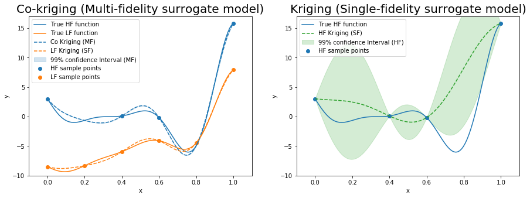

```python
plt.figure(figsize = (15, 5))
plt.subplot(1,2,1)
plt.plot(x, y_true_HF, '-C0', label='True HF function')
plt.plot(x, y_true_LF, '-C1', label='True LF function')
plt.plot(x, y_MF, '--C0', label='Co Kriging (MF)')
plt.fill_between(np.ravel(x), np.ravel(y_MF-3*np.sqrt(var_MF)),
                  np.ravel(y_MF+3*np.sqrt(var_MF)),
                  color='C0',alpha=0.2, label ='99% confidence Interval (MF)')
plt.plot(x, y_LF, '--C1', label='LF Kriging (SF)')

plt.scatter(xt_HF, yt_HF, marker='o', c='C0', label='HF sample points')
plt.scatter(xt_LF, yt_LF, marker='o', c='C1', label='LF sample points')
plt.ylim(-10, 17); plt.xlim(-0.1, 1.1)
plt.xlabel('x'); plt.ylabel('y')
plt.legend()
plt.title('Co-kriging (Multi-fidelity surrogate model)',fontsize='20')

plt.subplot(1,2,2)
plt.plot(x, HF_function(x), '-C0', label='True HF function')
plt.plot(x, y_HF_only, '--C2', label='HF Kriging (SF)')
plt.fill_between(np.ravel(x), np.ravel(y_HF_only-3*np.sqrt(var_HF_only)),
                  np.ravel(y_HF_only+3*np.sqrt(var_HF_only)),
                  color='C2',alpha=0.2, label ='99% confidence Interval (HF)')

plt.scatter(xt_HF, yt_HF, marker='o', c='C0', label='HF sample points')
plt.ylim(-10, 17); plt.xlim(-0.1, 1.1)
plt.xlabel('x'); plt.ylabel('y')
plt.title('Kriging (Single-fidelity surrogate model)',fontsize='20')
plt.legend();
```

### ※ **응용 문제**

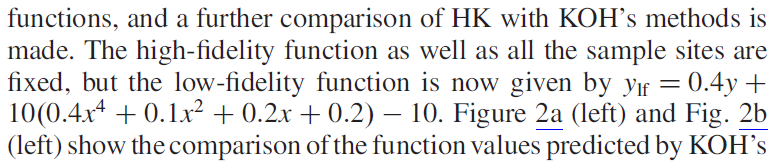

[출처] Han, Z. H., & Görtz, S. (2012). Hierarchical kriging model for variable-fidelity surrogate modeling. AIAA journal, 50(9), 1885-1896.

```python
ndim = 1
def HF_function(x): # HF 함수
    return ((x*6-2)**2)*np.sin((x*6-2)*2)

def LF_function(x): # LF 함수
    return 0.5*((x*6-2)**2)*np.sin((x*6-2)*2)+10*(x-0.5) - 5

# HF 인풋 데이터
xt_HF = np.array([0.0, 0.4, 0.6, 1.])

# LF 인풋 데이터
xt_LF = np.array([0.0, 0.2, 0.4, 0.6, 0.8, 1.])

# 아웃풋 데이터 생성 (실제 시뮬레이션 혹은 실험 수행)
yt_HF = HF_function(xt_HF) # 실제 HF 아웃풋 데이터 생성
yt_LF = LF_function(xt_LF) # 실제 LF 아웃풋 데이터 생성

# 대리모델링 (Main process, Co Kriging)
initial_theta = [0.1]*ndim # 초기 하이퍼파라미터 설정
sm_MF = MFK(theta0 = initial_theta, theta_bounds = [1e-6, 20], use_het_noise = False,
         propagate_uncertainty = False, n_start = 1)
sm_MF.set_training_values(xt_LF, yt_LF, name = 0) # LF 데이터 입력
sm_MF.set_training_values(xt_HF, yt_HF) # HF 데이터 입력
sm_MF.train() # 하이퍼파라미터 최적화

# 대리모델링 (Main process, Kriging)
sm_HF_only = KRG(theta0 = initial_theta)
sm_HF_only.set_training_values(xt_HF, yt_HF)
sm_HF_only.train() # 하이퍼파라미터 최적화

# 예측값 및 불확실 정보 (테스트)
x_want = np.array([0.2]) # 예측 포인트
y_want_MF = sm_MF.predict_values(x_want) # MF 예측값
s2_want_MF = np.sqrt(sm_MF.predict_variances(x_want)) # MF 불확실 정보

y_want_HF_only = sm_HF_only.predict_values(x_want) # HF 예측값
s2_want_HF_only = np.sqrt(sm_HF_only.predict_variances(x_want)) # HF 불확실 정보

y_real = HF_function(x_want) # 실제값

print("실제값",y_real)
print("예측값 (MF)","불확실 정보 (MF)",y_want_MF,s2_want_MF)
print("예측값 (HF)","불확실 정보 (HF)",y_want_HF_only,s2_want_HF_only)
```

```
___________________________________________________________________________

                                    MFK
___________________________________________________________________________

 Problem size

      # training points.        : 4

___________________________________________________________________________

 Training

   Training ...
   Training - done. Time (sec):  0.0299106
___________________________________________________________________________

                                  Kriging
___________________________________________________________________________

 Problem size

      # training points.        : 4

___________________________________________________________________________

 Training

   Training ...
   Training - done. Time (sec):  0.0679781
___________________________________________________________________________

 Evaluation

      # eval points. : 1

   Predicting ...
   Predicting - done. Time (sec):  0.0000000

   Prediction time/pt. (sec) :  0.0000000

___________________________________________________________________________

 Evaluation

      # eval points. : 1

   Predicting ...
   Predicting - done. Time (sec):  0.0000000

   Prediction time/pt. (sec) :  0.0000000

실제값 [-0.63972711]
예측값 (MF) 불확실 정보 (MF) [[-0.6397202]] [[0.00037096]]
예측값 (HF) 불확실 정보 (HF) [[2.47012261]] [[3.22518998]]
```

### ※ **정답 코드**

```python
ndim = 1
def HF_function(x): # HF 함수
    return ((x*6-2)**2)*np.sin((x*6-2)*2)

def LF_function(x): # LF 함수
    return 0.4*((x*6-2)**2)*np.sin((x*6-2)*2)+10*(0.4*x**4+0.1*x**2+0.2*x+0.2) - 10

# HF 인풋 데이터
xt_HF = np.array([0.0, 0.4, 0.6, 1.])

# LF 인풋 데이터
xt_LF = np.array([0.0, 0.1, 0.2, 0.3, 0.4, 0.5, 0.6, 0.7, 0.8, 0.9, 1.])

# 아웃풋 데이터 생성 (실제 시뮬레이션 혹은 실험 수행)
yt_HF = HF_function(xt_HF) # 실제 HF 아웃풋 데이터 생성
yt_LF = LF_function(xt_LF) # 실제 LF 아웃풋 데이터 생성

# 대리모델링 (Main process, Co Kriging)
initial_theta = [0.1]*ndim # 초기 하이퍼파라미터 설정
sm_MF = MFK(theta0 = initial_theta, theta_bounds = [1e-6, 20], use_het_noise = False,
         propagate_uncertainty = False, n_start = 1)
sm_MF.set_training_values(xt_LF, yt_LF, name = 0) # LF 데이터 입력
sm_MF.set_training_values(xt_HF, yt_HF) # HF 데이터 입력
sm_MF.train() # 하이퍼파라미터 최적화

# 대리모델링 (Main process, Kriging)
sm_HF_only = KRG(theta0 = initial_theta)
sm_HF_only.set_training_values(xt_HF, yt_HF)
sm_HF_only.train() # 하이퍼파라미터 최적화
```

```
___________________________________________________________________________

                                    MFK
___________________________________________________________________________

 Problem size

      # training points.        : 4

___________________________________________________________________________

 Training

   Training ...
   Training - done. Time (sec):  0.0309541
___________________________________________________________________________

                                  Kriging
___________________________________________________________________________

 Problem size

      # training points.        : 4

___________________________________________________________________________

 Training

   Training ...
   Training - done. Time (sec):  0.0888529
```

```python
# 예측값 및 불확실 정보 (테스트)
x_want = np.array([0.38]) # 예측 포인트
y_want_MF = sm_MF.predict_values(x_want) # MF 예측값
s2_want_MF = np.sqrt(sm_MF.predict_variances(x_want)) # MF 불확실 정보

y_want_HF_only = sm_HF_only.predict_values(x_want) # HF 예측값
s2_want_HF_only = np.sqrt(sm_HF_only.predict_variances(x_want)) # HF 불확실 정보

y_real = HF_function(x_want) # 실제값
```

```
___________________________________________________________________________

 Evaluation

      # eval points. : 1

   Predicting ...
   Predicting - done. Time (sec):  0.0009961

   Prediction time/pt. (sec) :  0.0009961

___________________________________________________________________________

 Evaluation

      # eval points. : 1

   Predicting ...
   Predicting - done. Time (sec):  0.0000000

   Prediction time/pt. (sec) :  0.0000000
```

```python
print("실제값",y_real)
print("예측값 (MF)","불확실 정보 (MF)",y_want_MF,s2_want_MF)
print("예측값 (HF)","불확실 정보 (HF)",y_want_HF_only,s2_want_HF_only)
```

```
실제값 [0.041645]
예측값 (MF) 불확실 정보 (MF) [[0.09303023]] [[0.00154442]]
예측값 (HF) 불확실 정보 (HF) [[0.40869304]] [[0.37885839]]
```

```python
# 시각화 (Post-processing)
num = 100
x = np.linspace(0.0, 1.0, num).reshape(-1, 1) # 0에서 1까지 등간격으로 num개의 x값을 생성

y_true_HF = HF_function(x) # 실제 HF 값
y_true_LF = LF_function(x) # 실제 LF 값

# MF (Co Kriging)
y_MF = sm_MF.predict_values(x) # MF의 예측값
var_MF = sm_MF.predict_variances(x) # MF의 불확실 정보

# LF (Kriging) --> Co Kriging이 만들어지면서 자연스럽게 생성됨
y_LF = sm_MF._predict_intermediate_values(x, 1) # LF의 예측값
var_LF, _ =  sm_MF.predict_variances_all_levels(x) # LF의 불확실 정보

# HF (Kriging)
y_HF_only = sm_HF_only.predict_values(x) # HF의 예측값
var_HF_only = sm_HF_only.predict_variances(x) # HF의 불확실 정보
```

```
___________________________________________________________________________

 Evaluation

      # eval points. : 100

   Predicting ...
   Predicting - done. Time (sec):  0.0009928

   Prediction time/pt. (sec) :  0.0000099

___________________________________________________________________________

 Evaluation

      # eval points. : 100

   Predicting ...
   Predicting - done. Time (sec):  0.0009949

   Prediction time/pt. (sec) :  0.0000099
```

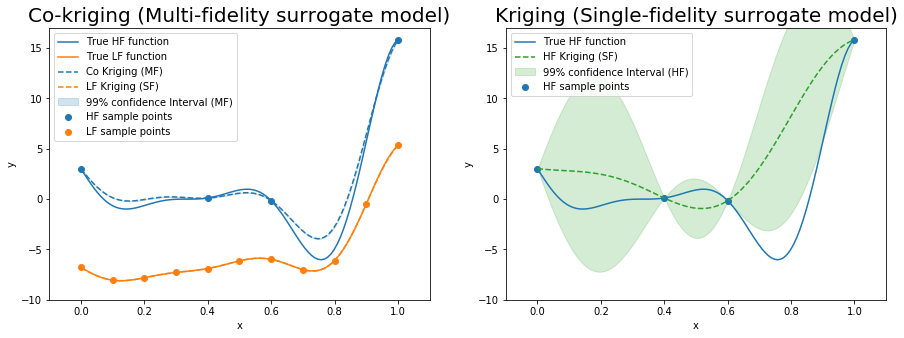

```python
plt.figure(figsize = (15, 5))
plt.subplot(1,2,1)
plt.plot(x, y_true_HF, '-C0', label='True HF function')
plt.plot(x, y_true_LF, '-C1', label='True LF function')
plt.plot(x, y_MF, '--C0', label='Co Kriging (MF)')
plt.fill_between(np.ravel(x), np.ravel(y_MF-3*np.sqrt(var_MF)),
                  np.ravel(y_MF+3*np.sqrt(var_MF)),
                  color='C0',alpha=0.2, label ='99% confidence Interval (MF)')
plt.plot(x, y_LF, '--C1', label='LF Kriging (SF)')

plt.scatter(xt_HF, yt_HF, marker='o', c='C0', label='HF sample points')
plt.scatter(xt_LF, yt_LF, marker='o', c='C1', label='LF sample points')
plt.ylim(-10, 17); plt.xlim(-0.1, 1.1)
plt.xlabel('x'); plt.ylabel('y')
plt.legend()
plt.title('Co-kriging (Multi-fidelity surrogate model)',fontsize='20')

plt.subplot(1,2,2)
plt.plot(x, HF_function(x), '-C0', label='True HF function')
plt.plot(x, y_HF_only, '--C2', label='HF Kriging (SF)')
plt.fill_between(np.ravel(x), np.ravel(y_HF_only-3*np.sqrt(var_HF_only)),
                  np.ravel(y_HF_only+3*np.sqrt(var_HF_only)),
                  color='C2',alpha=0.2, label ='99% confidence Interval (HF)')

plt.scatter(xt_HF, yt_HF, marker='o', c='C0', label='HF sample points')
plt.ylim(-10, 17); plt.xlim(-0.1, 1.1)
plt.xlabel('x'); plt.ylabel('y')
plt.title('Kriging (Single-fidelity surrogate model)',fontsize='20')
plt.legend();
```

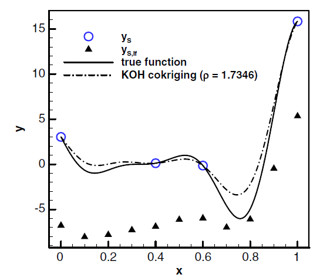

[출처] Han, Z. H., & Görtz, S. (2012). Hierarchical kriging model for variable-fidelity surrogate modeling. AIAA journal, 50(9), 1885-1896.